# EDAV Fall 2019 Final Project Group 23

# 3. Analyzing part

## 3.1 Word Cloud

Word Frequency and WordCloud from here:

```r
library(SnowballC)
library(wordcloud)
library(wordcloud2)
library(RColorBrewer)
mini <- Corpus(VectorSource(job$Minimum.Qual.Requirements))

# inspect(mini)
```

```r
toSpace <- content_transformer(function (x , pattern) gsub(pattern, " ", x))
mini <- tm_map(mini, toSpace, "/")
mini <- tm_map(mini, toSpace, "@")
mini <- tm_map(mini, toSpace, "\\|")
mini <- tm_map(mini, content_transformer(tolower))
```

```r
# Remove numbers
mini <- tm_map(mini, removeNumbers)
# Remove english common stopwords
mini <- tm_map(mini, removeWords, stopwords("english"))
# Remove your own stop word
# specify your stopwords as a character vector
mini <- tm_map(mini, removeWords, c("blabla1", "blabla2"))
# Remove punctuations
mini <- tm_map(mini, removePunctuation)
# Eliminate extra white spaces
mini <- tm_map(mini, stripWhitespace)
# Text stemming
mini <- tm_map(mini, stemDocument)
```

```r
dtm <- TermDocumentMatrix(mini)
m <- as.matrix(dtm)
v <- sort(rowSums(m), decreasing=TRUE)
d <- data.frame(word = names(v), freq=v)
head(d, 10)
```

```
##                      word  freq
## experi             experi 24957
## year                 year 21673
## accredit         accredit 12874
## educ                 educ 11423
## must                 must 10247
## colleg             colleg  9323
## one                   one  9247
## satisfactori satisfactori  8578
## describ           describ  8275
## fulltim           fulltim  7710
```

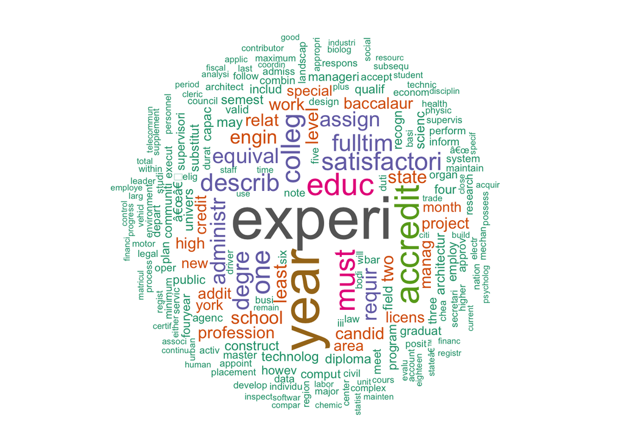

```r
set.seed(1234)
wordcloud(words = d$word, freq = d$freq, min.freq = 1,
          max.words=200, random.order=FALSE, rot.per=0.35,
          colors=brewer.pal(8, "Dark2"))
```

```r
wordcloud2(data = d)
```

[interactive chart not shown]

# 4. Conclusion

# 5. Future Works

# 6. Requirements and References

## 6.1 Reqirements

### 6.1.1 File format

(You don’t have to use the same format for this assignment – PSet 5, part A – and the final project itself.)

Choices are:

pdf_document

html_document

bookdown book: https://bookdown.org/yihui/bookdown/

shiny app: https://shiny.rstudio.com/

(Remember that it’s ok to have pieces of the project that don’t fit into the chosen output format; in those cases you can provide links to the relevant material.)

```
We decide to use the html_document as our output format.
```

### 6.1.2 Instructions

Be sure to review the final project instructions (https://edav.info/project.html), in particular the new section on reproducible workflow (https://edav.info/project.html#reproducible-workflow), which summarizes principles that we’ve discussed in class.

### 6.2 References